# Tugas-Kuliah-2

# Load Data & Cek Autokorelasi

```r
library(readxl)
```

```r
library(ggplot2)
library(car)
library(lmtest)
library(gridExtra)
data <- read_excel("C:/Users/VICTUS/Downloads/Book1.xlsx")
```

```r
head(data)
```

```
## # A tibble: 6 × 2
##   Tahun   IPM
##   <dbl> <dbl>
## 1  2010  68.8
## 2  2011  69.5
## 3  2012  69.7
## 4  2013  70.1
## 5  2014  70.7
## 6  2015  71.5
```

```r
model <- lm(IPM ~ Tahun, data = data)
summary(model)
```

```
##
## Call:
## lm(formula = IPM ~ Tahun, data = data)
##
## Residuals:
##      Min       1Q   Median       3Q      Max
## -0.38407 -0.28413 -0.05437  0.17908  0.54692
##
## Coefficients:
##               Estimate Std. Error t value Pr(>|t|)
## (Intercept) -1068.4616    44.3663  -24.08 1.58e-11 ***
## Tahun           0.5658     0.0220   25.72 7.28e-12 ***
## ---
## Signif. codes:  0 '***' 0.001 '**' 0.01 '*' 0.05 '.' 0.1 ' ' 1
##
## Residual standard error: 0.3319 on 12 degrees of freedom
## Multiple R-squared:  0.9822, Adjusted R-squared:  0.9807
## F-statistic: 661.3 on 1 and 12 DF,  p-value: 7.284e-12
```

```r
resid <- residuals(model)
fitted <- fitted.values(model)
```

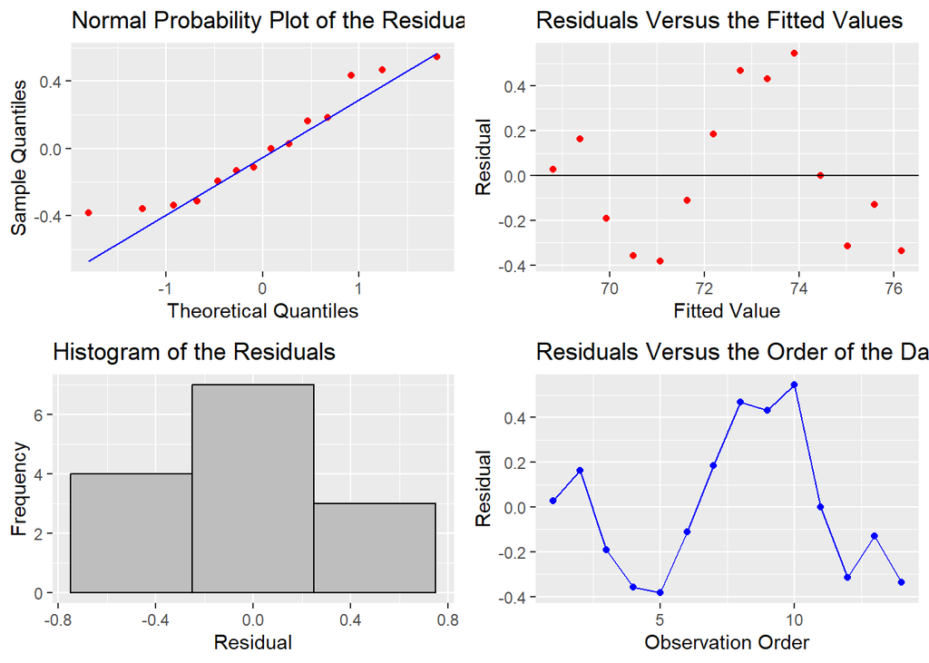

```r
p1 <- ggplot(data.frame(resid), aes(sample = resid)) +
  stat_qq(color = "red") +
  stat_qq_line(color = "blue") +
  labs(title = "Normal Probability Plot of the Residuals",
       x = "Theoretical Quantiles", y = "Sample Quantiles")

p2 <- ggplot(data.frame(fitted, resid), aes(x = fitted, y = resid)) +
  geom_point(color = "red") +
  geom_hline(yintercept = 0) +
  labs(x = "Fitted Value", y = "Residual",
       title = "Residuals Versus the Fitted Values")

p3 <- ggplot(data.frame(resid), aes(x = resid)) +
  geom_histogram(binwidth = 0.5, fill = "gray", color = "black") +
  labs(x = "Residual", y = "Frequency",
       title = "Histogram of the Residuals")

p4 <- ggplot(data.frame(Order = 1:length(resid), resid), aes(x = Order, y = resid)) +
  geom_point(color = "blue") +
  geom_line(color = "blue") +
  labs(x = "Observation Order", y = "Residual",
       title = "Residuals Versus the Order of the Data")

grid.arrange(p1, p2, p3, p4, ncol = 2)
```

Berdasarkan plot residual terhadap urutan observasi, terlihat adanya pola naik-turun yang cukup teratur sehingga menunjukkan indikasi adanya autokorelasi. Hal ini berarti residual tidak sepenuhnya acak, melainkan masih dipengaruhi oleh urutan waktu (tahun), sehingga model regresi antara tahun dan IPM Kabupaten Kulon Progo berpotensi mengalami masalah autokorelasi.

```r
dw_res <- dwtest(model)
dw_res
```

```
##
##  Durbin-Watson test
##
## data:  model
## DW = 0.68369, p-value = 0.0003801
## alternative hypothesis: true autocorrelation is greater than 0
```

Hasil uji Durbin-Watson menunjukkan nilai DW = 0.68 dengan p-value = 0.00038 < 0.05, sehingga dapat disimpulkan terdapat autokorelasi positif yang signifikan pada residual. Artinya, kesalahan (error) pada model regresi antara tahun dan IPM Kabupaten Kulon Progo saling berkorelasi antar periode, sehingga asumsi independensi residual tidak terpenuhi.

```r
resid <- residuals(model)
```

```r
shapiro.test(resid)
```

```
##
##  Shapiro-Wilk normality test
##
## data:  resid
## W = 0.9166, p-value = 0.1964
```

Hasil uji Shapiro-Wilk menunjukkan nilai W = 0.9166 dengan p-value = 0.1964 (> 0.05), sehingga tidak terdapat bukti yang cukup untuk menolak hipotesis nol. Artinya, residual pada model regresi antara tahun dan IPM Kabupaten Kulon Progo dapat dianggap berdistribusi normal.

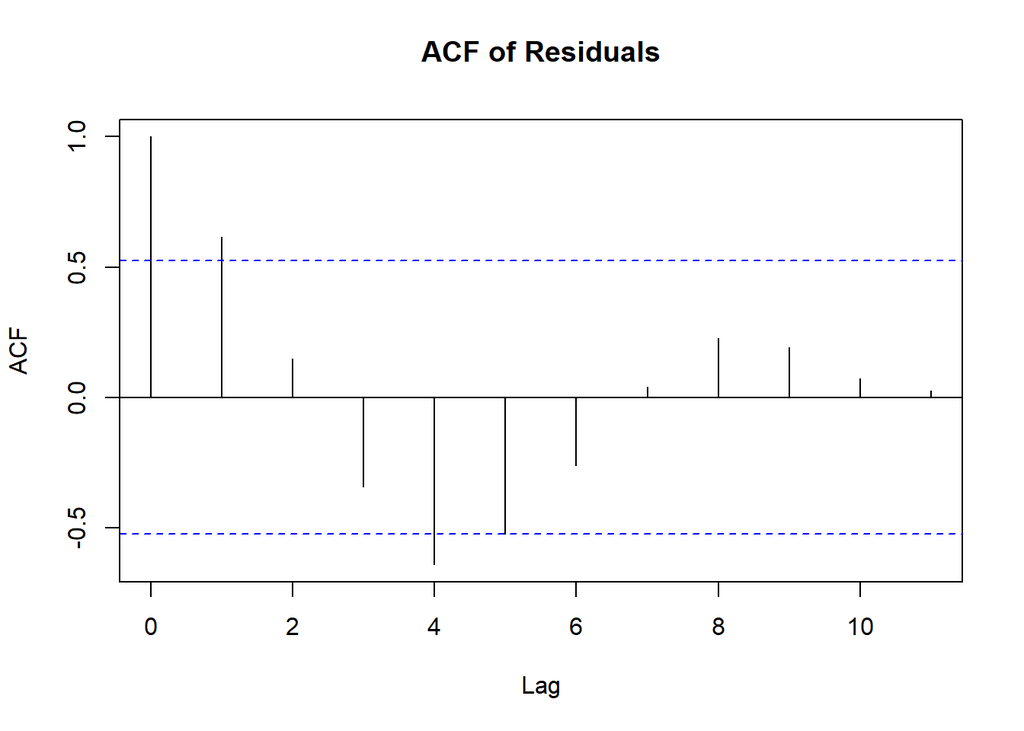

```r
acf(resid, main = "ACF of Residuals")
```

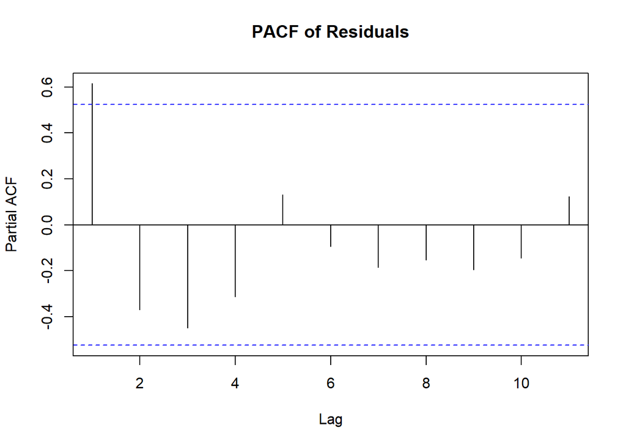

```r
pacf(resid, main = "PACF of Residuals")
```

Plot ACF menunjukkan adanya autokorelasi positif yang signifikan pada lag 1, sedangkan PACF juga menegaskan adanya pengaruh kuat pada lag 1. Hal ini konsisten dengan hasil uji Durbin-Watson sebelumnya yang mengindikasikan adanya autokorelasi positif. Dengan demikian, model regresi linear sederhana antara tahun dan IPM Kabupaten Kulon Progo tidak sepenuhnya memenuhi asumsi independensi residual.

# Transformasi

```r
install.packages("https://cran.r-project.org/src/contrib/Archive/orcutt/orcutt_2.0.tar.gz",
                 repos = NULL, type = "source")
library(orcutt)
library(HoRM)
```

## Metode Cochrane-Orcutt

```r
modelCO<-cochrane.orcutt(model)
modelCO
```

```
## Cochrane-orcutt estimation for first order autocorrelation
##
## Call:
## lm(formula = IPM ~ Tahun, data = data)
##
##  number of interaction: 10
##  rho 0.693511
##
## Durbin-Watson statistic
## (original):    0.68369 , p-value: 3.801e-04
## (transformed): 1.39203 , p-value: 6.251e-02
##
##  coefficients:
##  (Intercept)        Tahun
## -1016.815018     0.540193
```

Hasil estimasi menggunakan metode **Cochrane-Orcutt** menunjukkan adanya autokorelasi positif pada model awal dengan nilai Durbin-Watson sebesar 0.68 (p-value = 0.00038). Setelah dilakukan transformasi, nilai Durbin-Watson meningkat menjadi 1.39 (p-value = 0.0625) yang berarti masalah autokorelasi sudah tidak signifikan lagi pada taraf 5%. Model regresi yang dihasilkan setelah koreksi adalah:

$$\hat{IPM} = -1016.82 + 0.54 \times Tahun$$

Hal ini mengindikasikan bahwa Indeks Pembangunan Manusia (IPM) di Kabupaten Kulon Progo mengalami peningkatan rata-rata sekitar **0.54 poin setiap tahunnya**.

```r
rho<- modelCO$rho
rho
```

```
## [1] 0.6935111
```

```r
ipm <- data$IPM
tahun <- data$Tahun
```

```r
ipm[-1]
```

```
##  [1] 69.53 69.74 70.14 70.68 71.52 72.38 73.23 73.76 74.44 74.46 74.71 75.46
## [13] 75.82
```

```r
ipm.trans<- ipm[-1]-ipm[-14]*rho
tahun.trans<- tahun[-1]-tahun[-14]*rho
modelCOmanual<- lm(ipm.trans~tahun.trans)
summary(modelCOmanual)
```

```
##
## Call:
## lm(formula = ipm.trans ~ tahun.trans)
##
## Residuals:
##     Min      1Q  Median      3Q     Max
## -0.3345 -0.2360  0.1162  0.1610  0.3609
##
## Coefficients:
##               Estimate Std. Error t value Pr(>|t|)
## (Intercept) -311.64250   39.29117  -7.932 7.09e-06 ***
## tahun.trans    0.54019    0.06349   8.509 3.62e-06 ***
## ---
## Signif. codes:  0 '***' 0.001 '**' 0.01 '*' 0.05 '.' 0.1 ' ' 1
##
## Residual standard error: 0.2625 on 11 degrees of freedom
## Multiple R-squared:  0.8681, Adjusted R-squared:  0.8561
## F-statistic:  72.4 on 1 and 11 DF,  p-value: 3.618e-06
```

```r
b0bintang <- modelCOmanual$coefficients[-2]
b0 <- b0bintang/(1-rho)
b1 <- modelCOmanual$coefficients[-1]
b0
```

```
## (Intercept)
##   -1016.815
```

```r
b1
```

```
## tahun.trans
##   0.5401927
```

Hasil perhitungan manual sama dengan hasil yang dikeluarkan oleh packages.

## Metode Hildreth-Lu

```r
hildreth.lu.func<- function(r, model){
  x <- model.matrix(model)[,-1]
  y <- model.response(model.frame(model))
  n <- length(y)
  t <- 2:n
  y <- y[t]-r*y[t-1]
  x <- x[t]-r*x[t-1]

  return(lm(y~x))
}

r <- c(seq(0.1,0.9, by= 0.1))
tab <- data.frame("rho" = r, "SSE" = sapply(r, function(i){deviance(hildreth.lu.func(i, model))}))
round(tab, 4)
```

```
##   rho    SSE
## 1 0.1 1.1699
## 2 0.2 1.0428
## 3 0.3 0.9391
## 4 0.4 0.8587
## 5 0.5 0.8018
## 6 0.6 0.7682
## 7 0.7 0.7580
## 8 0.8 0.7713
## 9 0.9 0.8079
```

```r
rOpt <- seq(0.6,0.9, by= 0.001)
tabOpt <- data.frame("rho" = rOpt, "SSE" = sapply(rOpt, function(i){deviance(hildreth.lu.func(i, model))}))
head(tabOpt[order(tabOpt$SSE),])
```

```
##      rho       SSE
## 95 0.694 0.7579960
## 94 0.693 0.7579960
## 96 0.695 0.7579983
## 93 0.692 0.7579984
## 97 0.696 0.7580030
## 92 0.691 0.7580031
```

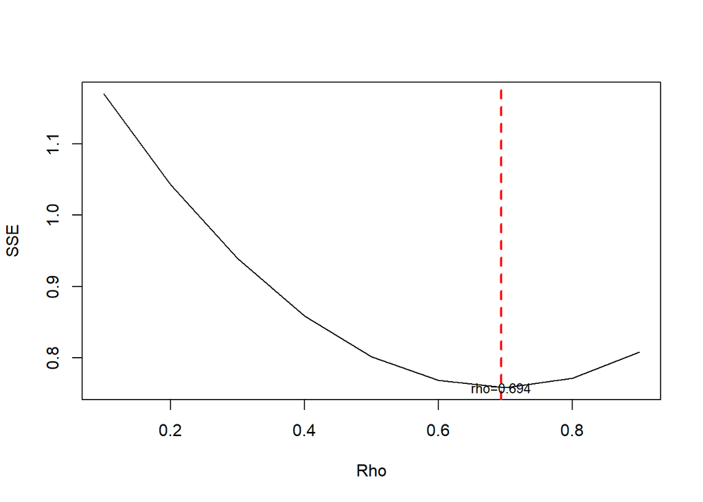

```r
par(mfrow = c(1,1))
plot(tab$SSE ~ tab$rho , type = "l", xlab = "Rho", ylab = "SSE")
abline(v = tabOpt[tabOpt$SSE==min(tabOpt$SSE),"rho"], lty = 2, col="red",lwd=2)
text(x=0.694, y=0.7579960, labels = "rho=0.694", cex = 0.8)
```

Hasil estimasi dengan metode Hildreth–Lu menunjukkan bahwa nilai rho optimal berada pada sekitar 0.694, yaitu titik dengan Sum of Squared Errors (SSE) paling minimum.

```r
modelHL <- hildreth.lu.func(0.694, model)
summary(modelHL)
```

```
##
## Call:
## lm(formula = y ~ x)
##
## Residuals:
##     Min      1Q  Median      3Q     Max
## -0.3347 -0.2359  0.1162  0.1612  0.3608
##
## Coefficients:
##               Estimate Std. Error t value Pr(>|t|)
## (Intercept) -311.10735   39.29128  -7.918 7.20e-06 ***
## x              0.54013    0.06359   8.494 3.68e-06 ***
## ---
## Signif. codes:  0 '***' 0.001 '**' 0.01 '*' 0.05 '.' 0.1 ' ' 1
##
## Residual standard error: 0.2625 on 11 degrees of freedom
## Multiple R-squared:  0.8677, Adjusted R-squared:  0.8557
## F-statistic: 72.15 on 1 and 11 DF,  p-value: 3.678e-06
```

```r
cat("y = ", coef(modelHL)[1]/(1-0.694), "+", coef(modelHL)[2],"x", sep = "")
```

```
## y = -1016.691+0.5401311x
```

```r
dwtest(modelHL)
```

```
##
##  Durbin-Watson test
##
## data:  modelHL
## DW = 1.3926, p-value = 0.06265
## alternative hypothesis: true autocorrelation is greater than 0
```

$$\hat{y} = -311.11 + 0.54x$$

$$\hat{y} = -1016.69 + 0.54x$$

dengan nilai Durbin–Watson meningkat menjadi 1.39 (p-value = 0.063), sehingga autokorelasi tidak lagi signifikan. Hal ini menunjukkan bahwa model hasil koreksi lebih reliabel dalam menjelaskan hubungan linear antara tahun dan IPM Kabupaten Kulon Progo.

# Kesimpulan

```r
sseModelawal <- anova(model)$`Sum Sq`[-1]
sseModelCO <- anova(modelCOmanual)$`Sum Sq`[-1]
sseModelHL <- anova(modelHL)$`Sum Sq`[-1]
mseModelawal <- sseModelawal/length(ipm)
mseModelCO <- sseModelCO/length(ipm)
mseModelHL <- sseModelHL/length(ipm)
akurasi <- matrix(c(sseModelawal,sseModelCO,sseModelHL,
                    mseModelawal,mseModelCO,mseModelHL),nrow=2,ncol=3,byrow = T)
colnames(akurasi) <- c("Model Awal", "Model Cochrane-Orcutt", "Model Hildreth-Lu")
row.names(akurasi) <- c("SSE","MSE")
akurasi
```

```
##     Model Awal Model Cochrane-Orcutt Model Hildreth-Lu
## SSE 1.32151253            0.75799573        0.75799601
## MSE 0.09439375            0.05414255        0.05414257
```

Berdasarkan hasil perbandingan, model awal memiliki nilai SSE = 1.32 dan MSE = 0.094, sedangkan setelah dilakukan koreksi autokorelasi dengan metode Cochrane–Orcutt dan Hildreth–Lu, nilai SSE dan MSE menurun menjadi sekitar 0.758 dan 0.054. Hal ini menunjukkan bahwa kedua metode koreksi mampu memperbaiki masalah autokorelasi dan menghasilkan model yang lebih baik. Karena nilai SSE dan MSE keduanya identik, maka model terbaik dapat dipilih baik dari metode Cochrane–Orcutt maupun Hildreth–Lu, dengan kinerja yang sama dalam meningkatkan reliabilitas model regresi IPM Kabupaten Kulon Progo terhadap tahun.